# 3006541G_ATUA_Exercise_2

GitHub：https://github.com/lijing-Guo/Lijing-Guo/tree/main/ATUA%20Exercise%202

```python
from google.colab import files
uploaded = files.upload()
```

Upload widget is only available when the cell has been executed in the current browser session. Please rerun this cell to enable.

```
Saving AssignmentData-LondonPM25Prediction.geojson to AssignmentData-LondonPM25Prediction.geojson
```

```python
!pip install geopandas libpysal networkx scikit-learn matplotlib torch-geometric numpy pandas shapely pyproj rtree
```

```
     ━━━━━━━━━━━━━━━━━━━━━━━━━━━━━━━━━━━━━━━━ 63.7/63.7 kB 4.2 MB/s eta 0:00:00
Downloading torch_geometric-2.7.0-py3-none-any.whl (1.3 MB)
   ━━━━━━━━━━━━━━━━━━━━━━━━━━━━━━━━━━━━━━━━ 1.3/1.3 MB 23.5 MB/s eta 0:00:00
```

```python
!pip install torch torchvision torchaudio --index-url https://download.pytorch.org/whl/cpu
```

```python
# Colab setup

import os
import math
import numpy as np
import pandas as pd
import geopandas as gpd
import matplotlib.pyplot as plt
import networkx as nx

import torch
import torch.nn.functional as F

plt.rcParams["figure.dpi"] = 140
print("torch:", torch.__version__)

from sklearn.model_selection import train_test_split
from sklearn.preprocessing import StandardScaler
from sklearn.metrics import mean_squared_error, r2_score
from sklearn.linear_model import LinearRegression
from sklearn.neighbors import NearestNeighbors


# PyG imports
from torch_geometric.data import Data
from torch_geometric.utils import from_networkx
from torch_geometric.nn import GCNConv, SAGEConv
```

```
torch: 2.10.0+cpu
```

# 1. Data Exploration

## 1.1 Load data

```python
gdf = gpd.read_file("AssignmentData-LondonPM25Prediction.geojson")
```

## 1.2 Inspect the attributes

```python
print("Shape:", gdf.shape)
print("\nColumns:")
print(gdf.columns.tolist())

print("\nData types:")
print(gdf.dtypes)

print("\nFirst 5 rows:")
display(gdf.head())

print("\nMissing values:")
display(gdf.isna().sum().sort_values(ascending=False).head(20))
```

```
Shape: (25053, 63)

Columns:
['oa_code', 'PM25', 'k001_PCT', 'k002_PCT', 'k003_PCT', 'k004_PCT', 'k005_PCT', 'k006_PCT', 'k007_RATIO', 'k008_PCT', 'k009_PCT', 'k010_PCT', 'k011_PCT', 'k012_PCT', 'k013_PCT', 'k014_PCT', 'k015_PCT', 'k016_PCT', 'k017_PCT', 'k018_PCT', 'k019_PCT', 'k020_PCT', 'k021_PCT', 'k022_PCT', 'k023_PCT', 'k…

Data types:
oa_code       object
PM25         float64
k001_PCT     float64
k002_PCT     float64
k003_PCT     float64
              ...
k057_PCT     float64
k058_PCT     float64
k059_PCT     float64
k060_PCT     float64
geometry    geometry
Length: 63, dtype: object

First 5 rows:
```

|  | oa_code | PM25 | k001_PCT | k002_PCT | k003_PCT | k004_PCT | k005_PCT | k006_PCT | k007_RATIO | k008_PCT | ... | k052_PCT | k053_PCT | k054_PCT | k055_PCT | k056_PCT | k057_PCT | k058_PCT | k059_PCT | k060_PCT | geometry |
| --- | --- | --- | --- | --- | --- | --- | --- | --- | --- | --- | --- | --- | --- | --- | --- | --- | --- | --- | --- | --- | --- |
| 0 | E00023264 | 16.037363 | 0.655567 | 0.733280 | 0.788337 | 0.809438 | 0.616867 | 0.048672 | 0.497994 | 0.116873 | ... | 0.801915 | 0.574316 | 0.565354 | 0.693873 | 0.607090 | 0.478002 | 0.509235 | 0.638862 | 0.662914 | MULTIPOLYGON (((527635.452 171810.058, 527495.... |
| 1 | E00003359 | 15.571575 | 0.747233 | 0.539689 | 0.833211 | 0.720010 | 0.659997 | 0.155885 | 0.389216 | 0.387319 | ... | 0.731722 | 0.346726 | 0.750254 | 0.730786 | 0.669715 | 0.548814 | 0.621092 | 0.667940 | 0.558571 | MULTIPOLYGON (((543581.516 171132.486, 543704 ... |
| 2 | E00023266 | 16.068834 | 0.689326 | 0.758308 | 0.780265 | 0.787414 | 0.633875 | 0.151961 | 0.542225 | 0.000000 | ... | 0.789704 | 0.603182 | 0.551503 | 0.630910 | 0.562070 | 0.614731 | 0.500493 | 0.624021 | 0.682385 | MULTIPOLYGON (((526613.539 171839.165, 526546.... |
| 3 | E00020264 | 18.205215 | 0.749280 | 0.701306 | 0.841211 | 0.773311 | 0.432955 | 0.000000 | 0.480711 | 0.000000 | ... | 0.712008 | 0.454649 | 0.413096 | 0.740138 | 0.831888 | 0.726281 | 0.377247 | 0.517599 | 0.540406 | MULTIPOLYGON (((533563.521 179695.146, 533351.... |
| 4 | E00023263 | 16.128491 | 0.716956 | 0.743201 | 0.823621 | 0.783315 | 0.621155 | 0.073256 | 0.532274 | 0.000000 | ... | 0.752003 | 0.656612 | 0.372115 | 0.741299 | 0.555038 | 0.692244 | 0.524108 | 0.657307 | 0.614341 | MULTIPOLYGON (((527822 172020, 527979 171903.0... |

5 rows × 63 columns

```
Missing values:
```

|  | 0 |
| --- | --- |
| oa_code | 0 |
| PM25 | 0 |
| k001_PCT | 0 |
| k002_PCT | 0 |
| k003_PCT | 0 |
| k004_PCT | 0 |
| k005_PCT | 0 |
| k006_PCT | 0 |
| k007_RATIO | 0 |
| k008_PCT | 0 |
| k009_PCT | 0 |
| k010_PCT | 0 |
| k011_PCT | 0 |
| k012_PCT | 0 |
| k013_PCT | 0 |
| k014_PCT | 0 |
| k015_PCT | 0 |
| k016_PCT | 0 |
| k017_PCT | 0 |
| k018_PCT | 0 |

**dtype:** int64

## 1.3 Inspect the geometry

```python
print("CRS:", gdf.crs)
print("\nGeometry types:")
print(gdf.geom_type.value_counts())

print("\nBounds:")
print(gdf.total_bounds)

print("\nMissing geometries:", gdf.geometry.isna().sum())
```

```
CRS: EPSG:27700

Geometry types:
MultiPolygon    25053
Name: count, dtype: int64

Bounds:
[503574.188 155850.798 561956.688 200933.609]

Missing geometries: 0
```

## 1.4 Examine the distribution of the PM2.5 values

```
count    25053.000000
mean        15.975608
std          0.783971
min         14.283266
25%         15.403583
50%         15.846878
75%         16.428663
max         21.100099
Name: PM25, dtype: float64
```

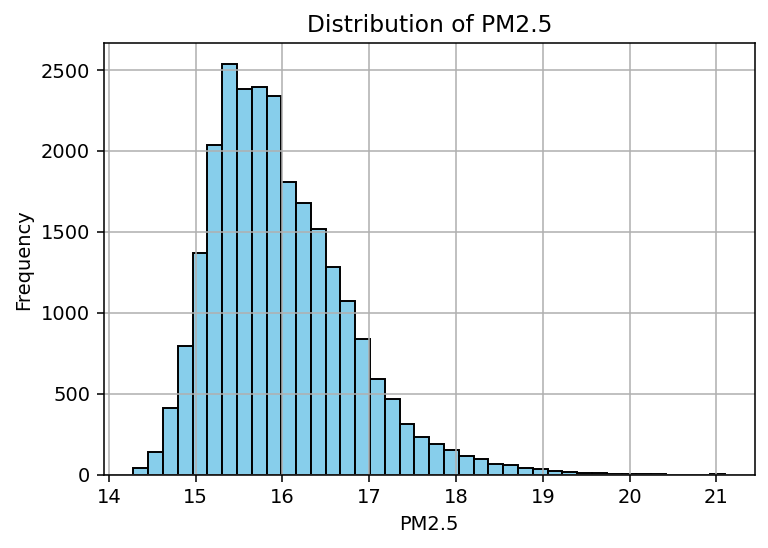

```python
print(gdf["PM25"].describe())

plt.figure(figsize=(6,4))
gdf["PM25"].hist(bins=40, color='skyblue', edgecolor='black')
plt.title("Distribution of PM2.5")
plt.xlabel("PM2.5")
plt.ylabel("Frequency")
plt.show()
```

## 1.5 Map of PM2.5 across London

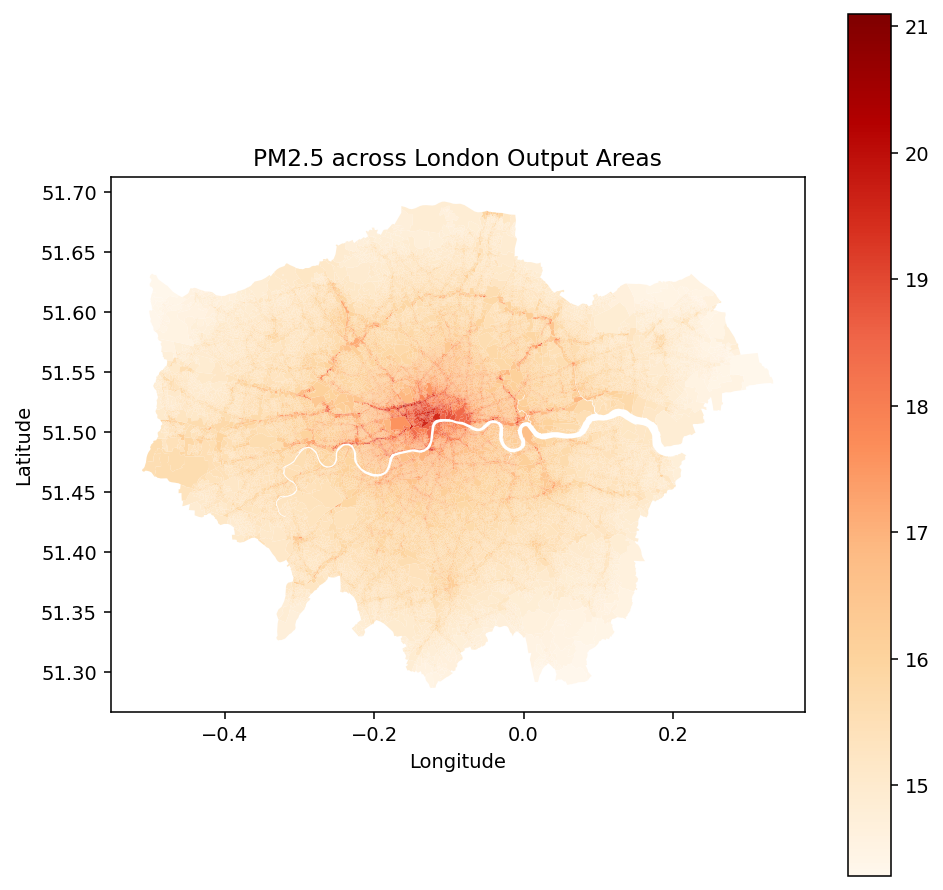

```python
gdf_plot = gdf.to_crs(epsg=4326)

fig, ax = plt.subplots(1, 1, figsize=(8, 8))
gdf_plot.plot(column="PM25", cmap="OrRd", linewidth=0, legend=True, ax=ax)
ax.set_title("PM2.5 across London Output Areas")
ax.set_xlabel("Longitude")
ax.set_ylabel("Latitude")
plt.show()
```

## 1.6 Identify which columns will be used as input features

```python
feature_cols = [c for c in gdf.columns if c not in ["oa_code", "PM25", "geometry"]]

print("Number of feature columns:", len(feature_cols))
print(feature_cols[:15])
```

```
Number of feature columns: 60
['k001_PCT', 'k002_PCT', 'k003_PCT', 'k004_PCT', 'k005_PCT', 'k006_PCT', 'k007_RATIO', 'k008_PCT', 'k009_PCT', 'k010_PCT', 'k011_PCT', 'k012_PCT', 'k013_PCT', 'k014_PCT', 'k015_PCT']
```

## 1.7 Prepare feature matrix X and target y

```python
X = gdf[feature_cols].copy()
y = gdf["PM25"].astype(np.float32).values

scaler = StandardScaler()
X_scaled = scaler.fit_transform(X).astype(np.float32)

print("X shape:", X_scaled.shape)
print("y shape:", y.shape)
```

```
X shape: (25053, 60)
y shape: (25053,)
```

This dataset contains 25,053 London Output Areas and 63 columns in total, including one identifier (oa_code), one target variable (PM25), 60 numerical urban attributes, and polygon geometry. The PM2.5 variable is the environmental indicator to be predicted, while the other attributes describe demographic, housing, socio-economic, and employment characteristics of each area. For example, the variables include density (k007), flats (k030), public transport (k042), private transport (k043), unemployment (k045), education (k059), and human health and social work activities (k060). These variables provide a broad socio-spatial profile of each Output Area and are therefore plausible predictors of environmental exposure.

The PM2.5 distribution suggests that air pollution levels vary across London, with a mean of 15.98, a standard deviation of 0.78, and values ranging from 14.28 to 21.10. Mapping PM2.5 helps reveal the spatial pattern of the target variable and confirms that this is a regression problem with meaningful spatial variation. Based on the assignment brief, I used all 60 numerical urban attributes as node features, while excluding oa_code, PM25, and geometry from the feature matrix.

# 2. Graph Construction

## 2.1 Calculate centroid

```python
gdf["centroid"] = gdf.geometry.centroid
coords = np.array([[geom.x, geom.y] for geom in gdf["centroid"]], dtype=np.float32)

print(coords.shape)
coords[:5]
```

```
(25053, 2)
```

```
array([[527526.44, 171947.69],
       [543811.6 , 170949.58],
       [526679.75, 171864.08],
       [533513.7 , 179855.84],
       [527863.2 , 171936.83]], dtype=float32)
```

## 2.2 Constructing the KNN graph

```python
k = 6

nbrs = NearestNeighbors(n_neighbors=k+1, algorithm="ball_tree")
nbrs.fit(coords)
distances, indices = nbrs.kneighbors(coords)

print("indices shape:", indices.shape)
print("distances shape:", distances.shape)
```

```
indices shape: (25053, 7)
distances shape: (25053, 7)
```

## 2.3 Convert to edge list

```python
edge_list = []

for i in range(indices.shape[0]):
    for j in indices[i][1:]:   # skip itself
        edge_list.append((i, j))
        edge_list.append((j, i))   # make graph undirected

edge_index_np = np.array(edge_list).T
print("edge_index shape:", edge_index_np.shape)
```

```
edge_index shape: (2, 300636)
```

## 2.4 Visualization graph

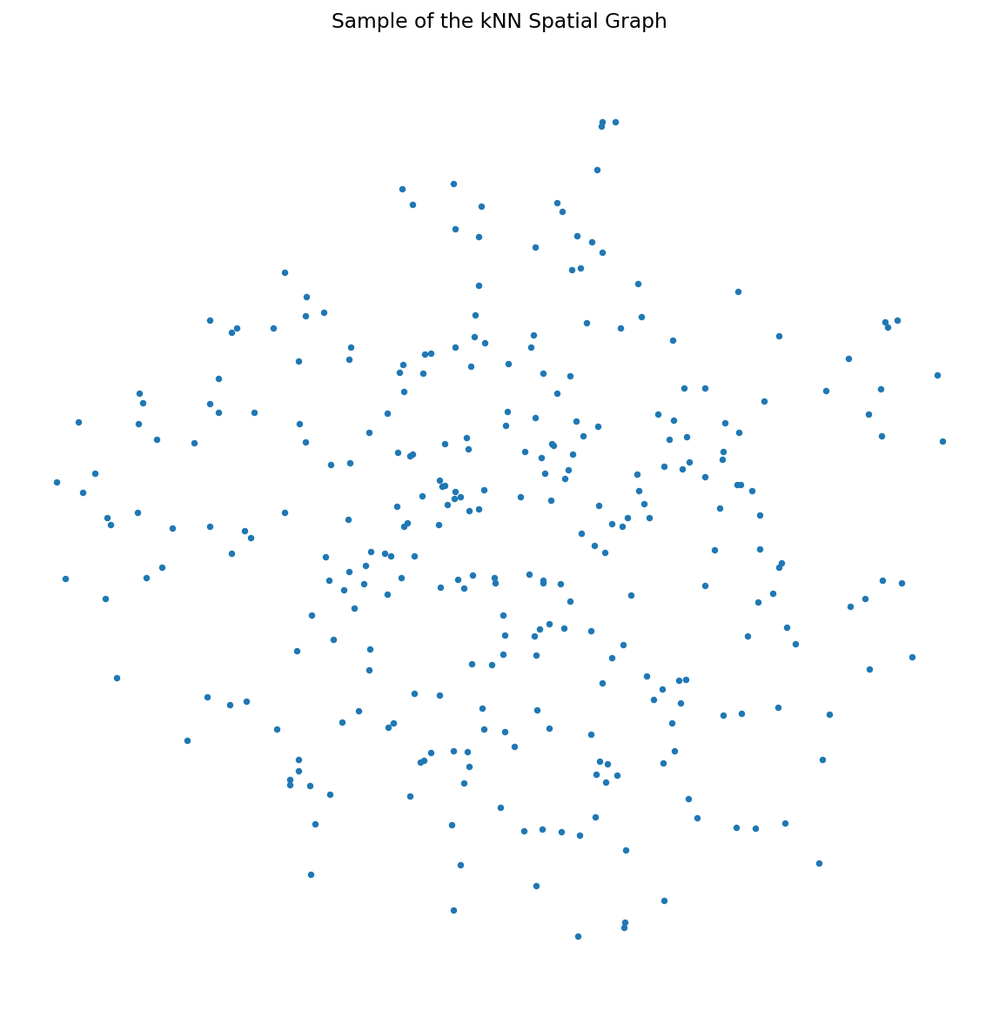

```python
sample_n = 300
rng = np.random.default_rng(42)
sample_idx = rng.choice(len(gdf), size=sample_n, replace=False)
sample_idx_set = set(sample_idx)

sample_edges = [
    (u, v) for u, v in zip(edge_index_np[0], edge_index_np[1])
    if u in sample_idx_set and v in sample_idx_set
]

G_sample = nx.Graph()
G_sample.add_nodes_from(sample_idx)
G_sample.add_edges_from(sample_edges)

pos = {i: coords[i] for i in sample_idx}

plt.figure(figsize=(8, 8))
nx.draw(G_sample, pos=pos, node_size=8, width=0.3, with_labels=False)
plt.title("Sample of the kNN Spatial Graph")
plt.show()
```

I constructed the graph using a centroid-based k-nearest neighbour approach, where each area was connected to its six nearest neighbours. I selected the kNN method because it guarantees that every node has local spatial connections, which is especially useful for a large and dense urban dataset such as London. Compared with polygon adjacency, kNN is also easier to implement and avoids isolated nodes.

This graph construction assumes that nearby areas are more likely to share similar environmental and urban characteristics. By representing local neighbourhood structure explicitly, the graph allows the GNN to aggregate information from surrounding Output Areas rather than relying only on each area’s own attributes. Although centroid-based kNN is a simplification of actual pollution processes, it provides a practical way to encode spatial relationships for graph learning.

# 3. Graph Neural Network Model

## 3.1 Linear Regression

```python
n = len(gdf)
all_idx = np.arange(n)

train_idx, test_idx = train_test_split(
    all_idx, test_size=0.2, random_state=42
)

X_train = X_scaled[train_idx]
X_test = X_scaled[test_idx]
y_train = y[train_idx]
y_test = y[test_idx]

lr_model = LinearRegression()
lr_model.fit(X_train, y_train)

lr_pred = lr_model.predict(X_test)

lr_rmse = np.sqrt(mean_squared_error(y_test, lr_pred))
lr_r2 = r2_score(y_test, lr_pred)

print("Linear Regression RMSE:", lr_rmse)
print("Linear Regression R2:", lr_r2)
```

```
Linear Regression RMSE: 0.38431542097623456
Linear Regression R2: 0.764856219291687
```

## 3.2 PyTorch Geometric Data

```python
x_tensor = torch.tensor(X_scaled, dtype=torch.float)
y_tensor = torch.tensor(y, dtype=torch.float).view(-1, 1)
edge_index = torch.tensor(edge_index_np, dtype=torch.long)

data = Data(x=x_tensor, edge_index=edge_index, y=y_tensor)
print(data)
```

```
Data(x=[25053, 60], edge_index=[2, 300636], y=[25053, 1])
```

## 3.3 Create train and test masks

```python
train_mask = torch.zeros(n, dtype=torch.bool)
test_mask = torch.zeros(n, dtype=torch.bool)

train_mask[train_idx] = True
test_mask[test_idx] = True

data.train_mask = train_mask
data.test_mask = test_mask

print("Training nodes:", int(train_mask.sum()))
print("Testing nodes:", int(test_mask.sum()))
```

```
Training nodes: 20042
Testing nodes: 5011
```

## 3.4 Define a two-layer GCN regressor

```python
class GCNRegressor(torch.nn.Module):
    def __init__(self, in_channels, hidden_channels=32, dropout=0.2):
        super().__init__()
        self.conv1 = GCNConv(in_channels, hidden_channels)
        self.conv2 = GCNConv(hidden_channels, 1)
        self.dropout = dropout

    def forward(self, x, edge_index):
        x = self.conv1(x, edge_index)
        x = F.relu(x)
        x = F.dropout(x, p=self.dropout, training=self.training)
        x = self.conv2(x, edge_index)
        return x
```

## 3.5 Define training function

```python
def train_model(model, data, epochs=200, lr=0.01, weight_decay=1e-4):
    optimizer = torch.optim.Adam(model.parameters(), lr=lr, weight_decay=weight_decay)
    loss_history = []

    for epoch in range(epochs):
        model.train()
        optimizer.zero_grad()

        out = model(data.x, data.edge_index)
        loss = F.mse_loss(out[data.train_mask], data.y[data.train_mask])

        loss.backward()
        optimizer.step()

        loss_history.append(loss.item())

        if epoch % 20 == 0:
            print(f"Epoch {epoch:03d} | Train MSE: {loss.item():.4f}")

    return loss_history
```

## 3.6 Train the GCN model

```python
torch.manual_seed(42)

gcn_model = GCNRegressor(
    in_channels=data.x.shape[1],
    hidden_channels=32,
    dropout=0.2
)

gcn_loss = train_model(gcn_model, data, epochs=200, lr=0.01)
```

```
Epoch 000 | Train MSE: 270.4370
Epoch 020 | Train MSE: 33.4365
Epoch 040 | Train MSE: 14.8234
Epoch 060 | Train MSE: 8.8410
Epoch 080 | Train MSE: 6.7948
Epoch 100 | Train MSE: 5.6225
Epoch 120 | Train MSE: 4.7576
Epoch 140 | Train MSE: 4.3720
Epoch 160 | Train MSE: 4.1637
Epoch 180 | Train MSE: 3.7965
```

## 3.7 Plot training loss

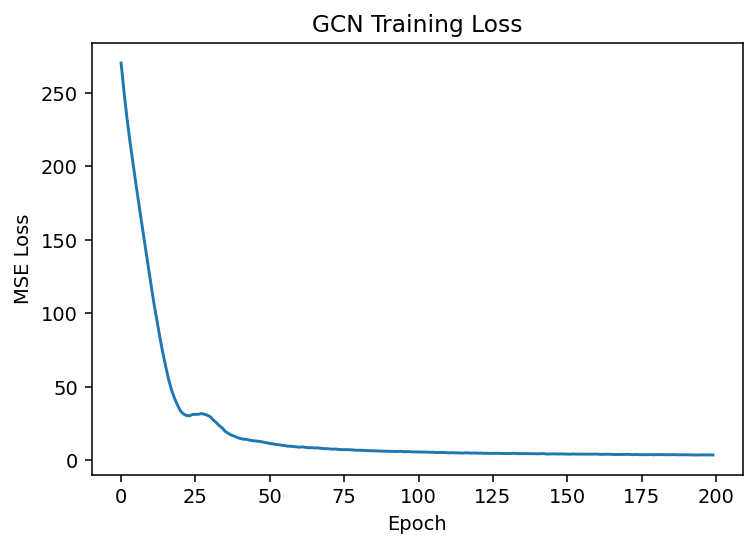

```python
plt.figure(figsize=(6,4))
plt.plot(gcn_loss)
plt.title("GCN Training Loss")
plt.xlabel("Epoch")
plt.ylabel("MSE Loss")
plt.show()
```

## 3.8 Evaluate GCN performance

```python
gcn_model.eval()
with torch.no_grad():
    gcn_pred_all = gcn_model(data.x, data.edge_index).view(-1).cpu().numpy()

gcn_pred_test = gcn_pred_all[test_idx]

gcn_rmse = np.sqrt(mean_squared_error(y_test, gcn_pred_test))
gcn_r2 = r2_score(y_test, gcn_pred_test)

print("GCN RMSE:", gcn_rmse)
print("GCN R2:", gcn_r2)
```

```
GCN RMSE: 1.5425591420067968
GCN R2: -2.788275718688965
```

## 3.9 Compare baseline and GCN

```python
results = pd.DataFrame({
    "Model": ["Linear Regression", "GCN"],
    "RMSE": [lr_rmse, gcn_rmse],
    "R2": [lr_r2, gcn_r2]
})

results
```

|  | Model | RMSE | R2 |
| --- | --- | --- | --- |
| 0 | Linear Regression | 0.384315 | 0.764856 |
| 1 | GCN | 1.542559 | -2.788276 |

To provide a benchmark, I first trained a simple Linear Regression model using only the 60 area-level attributes. Then I implemented a two-layer Graph Convolutional Network (GCN) in PyTorch Geometric, which combine node features, graph edges, and graph convolution layers in a basic GNN architecture. In this setup, the node features were the urban attributes and the graph edges were the k-nearest neighbour spatial connections.

The model results show a clear contrast between the non-spatial baseline and the graph-based approach. The GCN produced an RMSE of 1.5426 and an R² of -2.7883, which indicates very poor predictive performance. A negative R² means that the current GCN performed worse than a simple mean-based prediction benchmark, suggesting that the model did not successfully learn the relationship between the node attributes, the graph structure, and PM2.5 concentration. Therefore, in this experiment, the graph-based model did not outperform the simpler baseline.

# 4. Results and Interpretation

## 4.1 Prediction vs actual plot

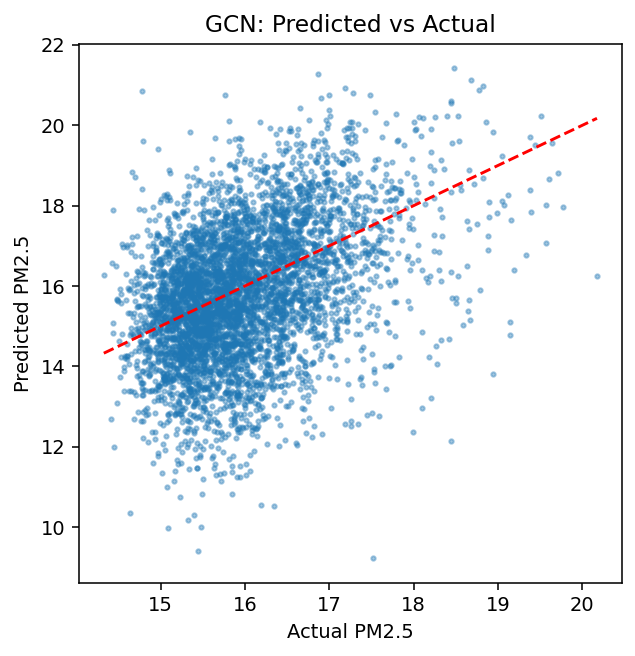

```python
plt.figure(figsize=(5,5))
plt.scatter(y_test, gcn_pred_test, s=5, alpha=0.4)
plt.plot(
    [y_test.min(), y_test.max()],
    [y_test.min(), y_test.max()],
    "r--"
)
plt.xlabel("Actual PM2.5")
plt.ylabel("Predicted PM2.5")
plt.title("GCN: Predicted vs Actual")
plt.show()
```

## 4.2 predicted PM2.5 map

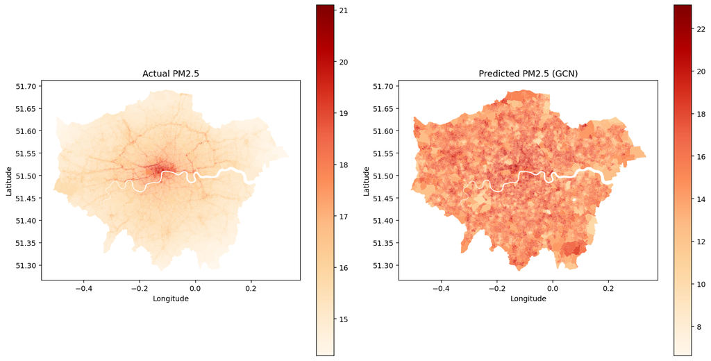

```python
gdf["PM25_pred_gcn"] = gcn_pred_all
gdf_map = gdf.to_crs(epsg=4326)

fig, axes = plt.subplots(1, 2, figsize=(14, 7))

gdf_map.plot(column="PM25", cmap="OrRd", linewidth=0, legend=True, ax=axes[0])
axes[0].set_title("Actual PM2.5")
axes[0].set_xlabel("Longitude")
axes[0].set_ylabel("Latitude")

gdf_map.plot(column="PM25_pred_gcn", cmap="OrRd", linewidth=0, legend=True, ax=axes[1])
axes[1].set_title("Predicted PM2.5 (GCN)")
axes[1].set_xlabel("Longitude")
axes[1].set_ylabel("Latitude")

plt.tight_layout()
plt.show()
```

## 4.3 Error Map

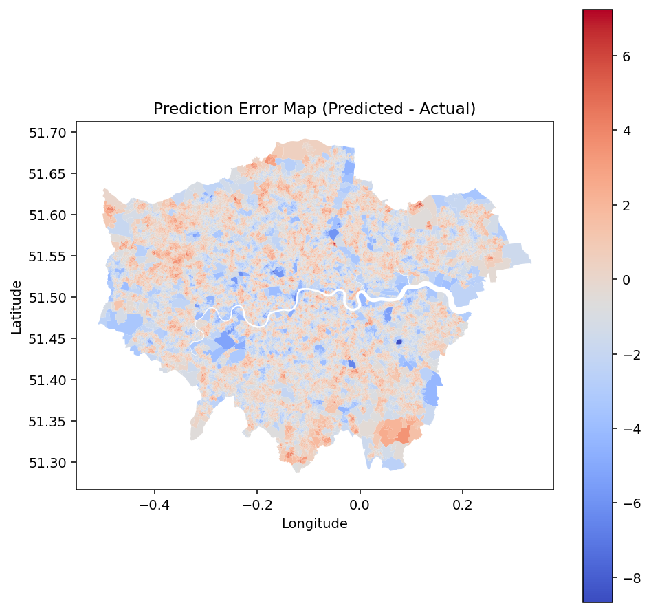

```python
gdf["error_gcn"] = gdf["PM25_pred_gcn"] - gdf["PM25"]
gdf_error = gdf.to_crs(epsg=4326)

fig, ax = plt.subplots(1, 1, figsize=(8, 8))
gdf_error.plot(column="error_gcn", cmap="coolwarm", linewidth=0, legend=True, ax=ax)
ax.set_title("Prediction Error Map (Predicted - Actual)")
ax.set_xlabel("Longitude")
ax.set_ylabel("Latitude")
plt.show()
```

The prediction-versus-actual plot and the predicted PM2.5 map were used to assess how well the model reproduced the observed pollution pattern across London. Because the GCN achieved a high RMSE and a negative R², the prediction-versus-actual plot is expected to show substantial scatter away from the 1:1 line, indicating weak predictive accuracy. Similarly, the predicted PM2.5 map is useful for examining whether the model captured any broad spatial gradients, even though the numerical performance remained poor.

These results suggest that spatial relationships are theoretically relevant but were not successfully leveraged by the current model. In principle, nearby Output Areas may share similar built form, transport conditions, and environmental exposure, so incorporating neighbourhood structure should help prediction. However, in this case, adding a graph structure did not improve performance. This may reflect limitations in the chosen graph design, the simplicity of the model, or the lack of more directly relevant predictors such as traffic intensity, land use, industrial sources, and meteorological variables. The experiment therefore highlights both the potential and the practical difficulty of applying GNNs to urban environmental prediction.